# practical_exercise_3, Methods 3, 2021, autumn semester

Laura W. Paaby

4/9 - 2021

```r
#loading libraries:
pacman::p_load(tidyverse, readbulk, patchwork, lmerTest, ggpubr, dfoptim)
```

added new line

# Exercises and objectives

The objectives of the exercises of this assignment are:  
1) Download and organise the data and model and plot staircase responses based on fits of logistic functions  
2) Fit multilevel models for response times  
3) Fit multilevel models for count data

REMEMBER: In your report, make sure to include code that can reproduce the answers requested in the exercises below (**MAKE A KNITTED VERSION**)  
REMEMBER: This assignment will be part of your final portfolio

## Exercise 1

Go to https://osf.io/ecxsj/files/ and download the files associated with Experiment 2 (there should be 29).  
The data is associated with Experiment 2 of the article at the following DOI https://doi.org/10.1016/j.concog.2019.03.007

1. Put the data from all subjects into a single data frame

```r
data<- as.tibble(read_bulk("experiment_2", fun = read_csv))
```

[output not shown]

[output not shown]

[output not shown]

[output not shown]

[output not shown]

[output not shown]

[output not shown]

[output not shown]

[output not shown]

[output not shown]

[output not shown]

[output not shown]

[output not shown]

[output not shown]

[output not shown]

[output not shown]

[output not shown]

[output not shown]

[output not shown]

[output not shown]

[output not shown]

[output not shown]

[output not shown]

[output not shown]

[output not shown]

[output not shown]

[output not shown]

[output not shown]

[output not shown]

2. Describe the data and construct extra variables from the existing variables
   1. add a variable to the data frame and call it *correct* (have it be a *logical* variable). Assign a 1 to each row where the subject indicated the correct answer and a 0 to each row where the subject indicated the incorrect answer (**Hint:** the variable *obj.resp* indicates whether the subject answered “even”, *e* or “odd”, *o*, and the variable *target_type* indicates what was actually presented.

```r
#the target.type and the obj.response should match
data$correct <- ifelse((data$obj.resp == "o" & data$target.type =="odd") | (data$obj.resp == "e" & data$target.type =="even"), 1,0)

#skimming the data to see the classes of the variables
ls.str(data)
```

```
## correct :  num [1:18131] 1 1 1 1 1 1 1 1 1 1 ...
## cue :  num [1:18131] 29 29 29 29 29 29 29 29 29 29 ...
## even.digit :  num [1:18131] 8 4 4 4 4 4 4 4 4 8 ...
## File :  chr [1:18131] "001.csv" "001.csv" "001.csv" "001.csv" "001.csv" "001.csv" ...
## jitter.x :  num [1:18131] -0.3425 0.0623 -0.4058 -0.3615 0.2891 ...
## jitter.y :  num [1:18131] 0.4489 0.0291 0.4995 -0.2224 0.4132 ...
## obj.resp :  chr [1:18131] "o" "e" "e" "o" "e" "e" "o" "o" "e" "o" "o" "e" "o" "o" "o" ...
## odd.digit :  num [1:18131] 9 9 7 7 7 7 7 7 9 9 ...
## pas :  num [1:18131] 4 4 4 4 4 4 4 4 4 4 ...
## rt.obj :  num [1:18131] 1.158 2.456 0.951 0.62 0.95 ...
## rt.subj :  num [1:18131] 1.754 1.39 0.686 0.653 0.582 ...
## seed :  num [1:18131] 9817 9817 9817 9817 9817 ...
## subject :  chr [1:18131] "001" "001" "001" "001" "001" "001" "001" "001" "001" "001" ...
## target.contrast :  num [1:18131] 1 1 0.9 0.9 0.8 0.8 0.5 0.5 0.3 0.3 ...
## target.frames :  num [1:18131] 3 3 3 3 3 3 3 3 3 3 ...
## target.type :  chr [1:18131] "odd" "even" "even" "odd" "even" "even" "odd" "odd" "even" ...
## task :  chr [1:18131] "pairs" "pairs" "pairs" "pairs" "pairs" "pairs" "pairs" ...
## trial :  num [1:18131] 0 1 2 3 4 5 6 7 8 9 ...
## trial.type :  chr [1:18131] "staircase" "staircase" "staircase" "staircase" "staircase" ...
```

[output not shown]

```r
#trial_type: trial type is at the moment a character, but should be a factor, so that the performance can be modeled and compared by which trial was done
data$trial.type <- as.factor(data$trial.type)


#pas: pas indicates whether you have seen the stimulus or not: 1, meaning you just got a tiny glimpse to 4, you saw it properly. It should be a factor since it is a categorical ordered variable.
data$pas <- as.factor(data$pas)

#target.contrast: is the contrast in the stimulus shown, it varies of in the different trials. It is numeric, and should stay in that way since *
data$target.contrast <- as.numeric(data$target.contrast)

#trial: number of trial, which reset as the experiment begins
data$trial <- as.factor(data$trial)

#cue: is 36 different combinations of numbers participants can be cued with, 3 types depending on the task setting.
data$cue <- as.factor(data$cue)

#task: is a character and should be a factor. It is the task setting, and can be either singles, paired or quadruplets referring to the amount of letters showing in the cue.
data$task <- as.factor(data$task)


#target_type:was a character, should be a factor - it is the contrast of the stimulus compared to the background*
data$target.type <- as.factor(data$target.type)

#rt.subj: reaction time of the rating of the pass. This is numeric data and should stay that way, since we are dealing with reacting time, which here is a continuous variable.

#rt.obj: reaction time of the answer on the task. Same as rt.subj

#obj.resp: the subject's to if the letter is odd or even, thus binomial and should be a factor
data$obj.resp <- as.factor(data$obj.resp)

#subject: the ID of the participant.
data$subject <- as.factor(data$subject)

#correct: indicates whether the subject answered correct 1 or wrong 0 when answering whether the letter was odd or even. It should be a binomial and categorical factor.
data$correct <- as.factor(data$correct)
```

[output not shown]

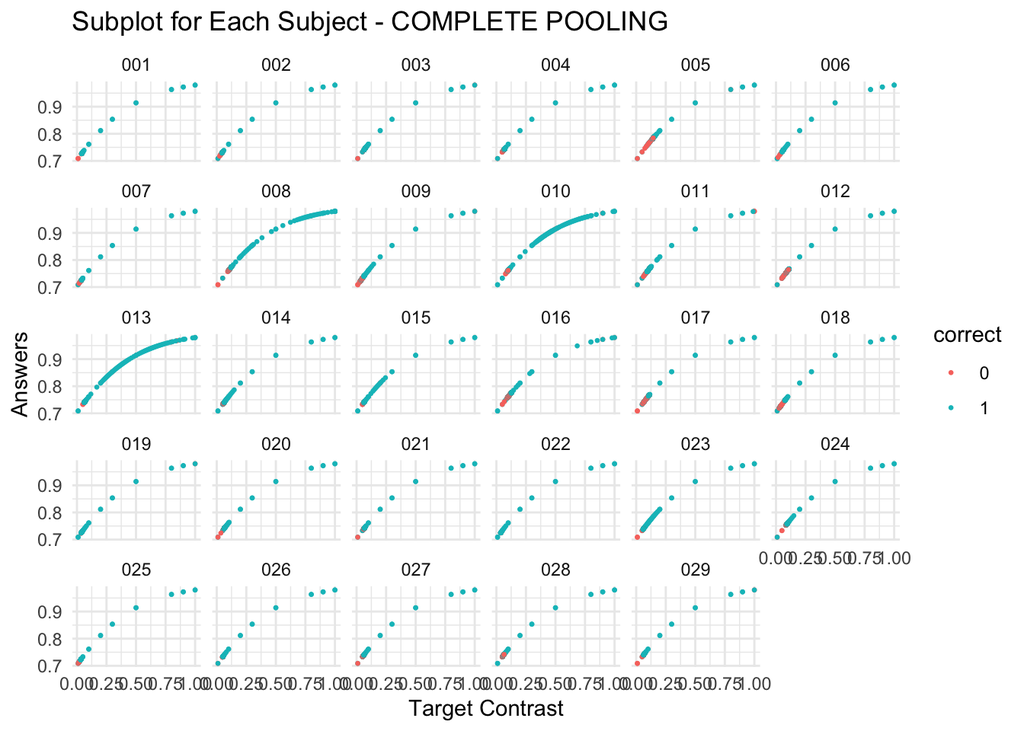

```r
df_m <- data %>%
  filter(trial.type == "staircase")


#model for COMPLETE pooling!!!!
trial_model<- glm(correct ~ target.contrast, data = df_m, family = "binomial")
fitted_y <- fitted(trial_model)

plot1 <- ggplot(df_m, aes(target.contrast, fitted_y, color = correct)) +
    geom_point(size =0.5)+
    facet_wrap(~subject) +
    theme_minimal()+
    xlab("Target Contrast")+
    ylab('Answers') +
    ggtitle("Subplot for Each Subject - COMPLETE POOLING")



#model for NO pooling:
##### meaning that we only take into account the individual and does not pool the data together.
no.pool <- glm(correct ~ target.contrast + subject + subject:target.contrast, data = df_m, family = "binomial" )
fit_np <- fitted(no.pool)

plot2 <- ggplot(df_m, aes(target.contrast, fit_np, color = correct)) +
    geom_point(size = 0.5)+
    facet_wrap(~subject) +
    theme_minimal()+
    xlab("Target Contrast")+
    ylab('Answers') +
    ggtitle("Subplot for Each Subject - NO POOLING")

plot1
```

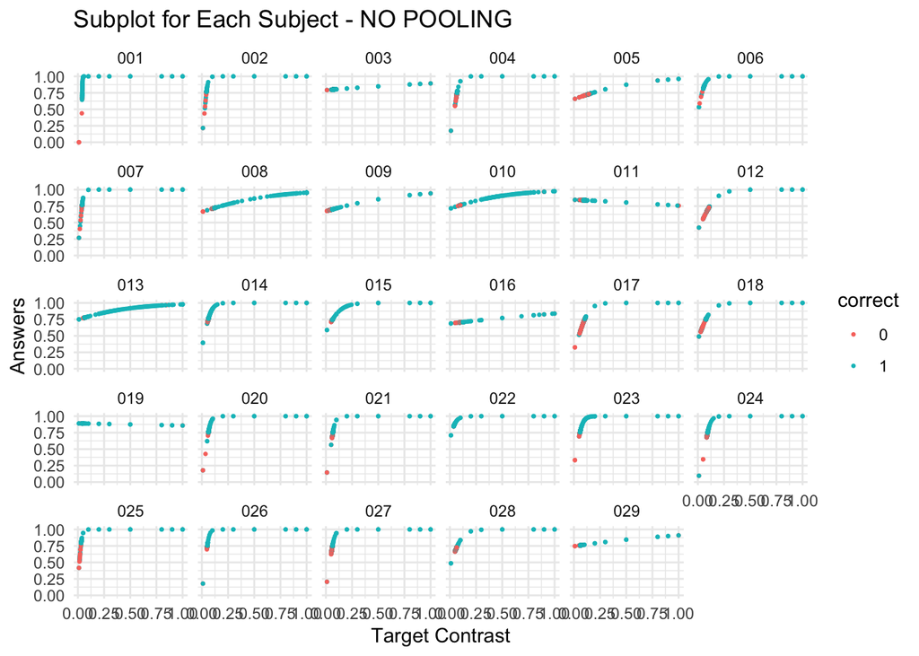

```r
plot2
```

*for the training I made both a no pool and complete pool after the best of my knowledge, which indicates how big of a difference that makes. However non of them seem to fit the data that well.*

*These are both supposed to follow a sigmoid function, assuming the relation i logistic, but this is not really the case. There appears to be a ceiling effect, since almost all subjects had way more correct answers than wrong, meaning almost all of the points are at y = 1.*

[figure not shown]

```
iv. on top of those plots, add the estimated functions (on the _target.contrast_ range from 0-1) for each subject based on partial pooling model (use `glmer` from the package `lme4`) where unique intercepts and slopes for _target.contrast_ are modelled for each _subject_
```

```r
#complete pooling with observed y-values.
plot3 <- ggplot(df_m, aes(target.contrast, correct, color = correct)) +
    geom_point(size =0.5)+
    facet_wrap(~subject) +
    theme_minimal()+
    xlab("Target Contrast")+
    ylab('Correct') +
    ggtitle("Subplot for Each Subject - COMPLETE POOLING")

plot3
```

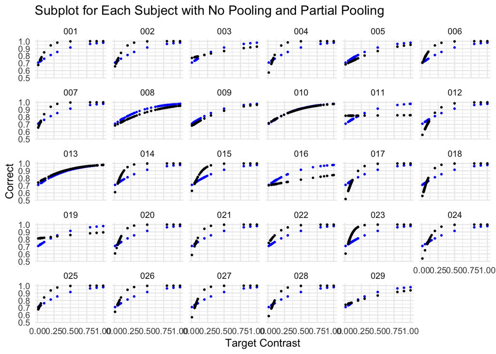

```r
#partial pooled model:
library(lme4)
part.pool.model <- glmer(correct ~ target.contrast + (target.contrast|subject), family = "binomial", data = df_m)

part.fit <- fitted(part.pool.model)


plot3 <- ggplot(df_m, aes(target.contrast, fitted_y)) +
    geom_point(colour = 'blue', size = 0.5)+
    geom_point(aes(y=part.fit), colour = 'black', size = 0.5) +
    facet_wrap(~subject) +
    theme_minimal()+
    xlab("Target Contrast")+
    ylab('Correct') +
    ggtitle("Subplot for Each Subject with No Pooling and Partial Pooling")

plot3
```

```
v. in your own words, describe how the partial pooling model allows for a better fit for each subject
```

*When partial pooling we are able to take into account both the average and each level of the categorical predictor. Hereby the model are more generalizable. The partial pooled points also appears to follow a sigmoid function a bit better than the not-pooled.*

## Exercise 2

Now we **only** look at the *experiment* trials (*trial.type*)

1. Pick four subjects and plot their Quantile-Quantile (Q-Q) plots for the residuals of their objective response times (*rt.obj*) based on a model where only intercept is modelled

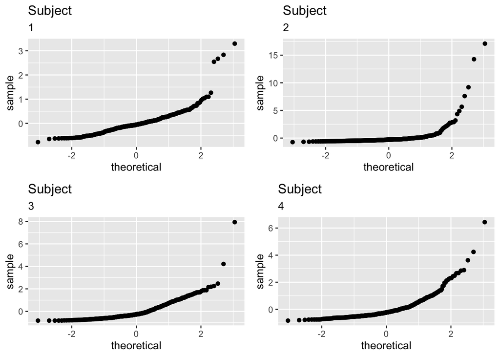

```r
#making a dataframe only containing the experimental trials.
experi.df <- data %>% filter(trial.type == "experiment")

df_1 <- experi.df %>%
    filter(subject == "001")
df_2 <- experi.df %>%
    filter(subject == "002")
df_3 <- experi.df %>%
    filter(subject == "003")
df_4 <- experi.df %>%
    filter(subject == "004")

#making the models for each subject's response time, with only the intercept modeled
m1 <- lm(rt.obj ~ 1, data = df_1)
m2 <- lm(rt.obj ~ 1, data = df_2)
m3 <- lm(rt.obj ~ 1, data = df_3)
m4 <- lm(rt.obj ~ 1, data = df_4)


#a function that plots a qq plot for the residuals of the given model
qq_f <- function(data.i, model.i, subject.i){
  plot <- data.i %>%
    ggplot(aes(sample = resid(model.i)))+
    geom_point(stat ="qq")+
    ggtitle("Subject", as.character(subject.i))

}

q1 <- qq_f(df_1, m1, 001)
q2 <- qq_f(df_2, m2, 002)
q3 <- qq_f(df_3, m3, 003)
q4 <- qq_f(df_4, m4, 004)

ggarrange(q1, q2, q3, q4)
```

i. comment on these  
*It appears as if the values needs a transformation, since it looks rather skewed and doesn’t look normally distributed.*

```
ii. does a log-transformation of the response time data improve the Q-Q-plots?
```

*make the exact same thing, but with log around the rt.obj in each model*

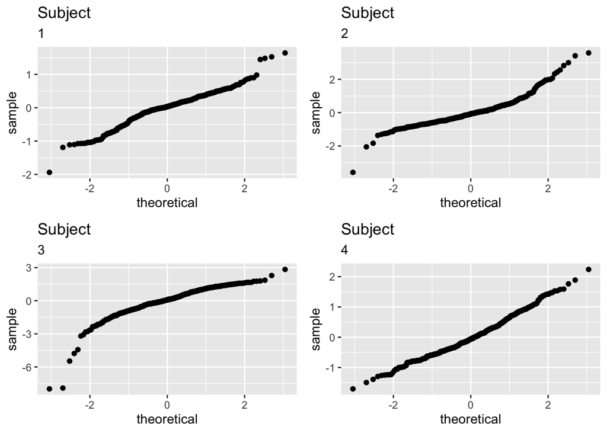

```r
#making the logged models
m1_log <- lm(log(rt.obj) ~ 1, data = df_1)
m2_log <- lm(log(rt.obj) ~ 1, data = df_2)
m3_log <- lm(log(rt.obj) ~ 1, data = df_3)
m4_log <- lm(log(rt.obj) ~ 1, data = df_4)

#using the functions to plot the qqplot over residuals now over the logged models
p1log <- qq_f(df_1, m1_log, 001)
p2log <- qq_f(df_2, m2_log, 002)
p3log <- qq_f(df_3, m3_log, 003)
p4log <- qq_f(df_4, m4_log, 004)

ggarrange(p1log, p2log, p3log, p4log)
```

2. Now do a partial pooling model modelling objective response times as dependent on *task*? (set `REML=FALSE` in your `lmer`-specification)  
   *this is done to the entire data set - I’m not sure however if what it asked is to only make the model on the four chosen participants. A sample size that small just doesn’t seem that generalizable to me, so I went with all the participants.*
   1. which would you include among your random effects and why? (support your choices with relevant measures, taking into account variance explained and number of parameters going into the modelling) *Both subject and trial are chosen as random intercepts, since I’d argue that each subject must have a uniqe baseline when entering the task. This could be both their mental state, memory, IQ etc., which means that they should be compared to their own performance between tasks to take such factors into account, as well as the average across the group. I have chosen to make trials a random intercept as well, since the type and difficulty of trial might be affecting the performance.*

```r
#partial pooling model:
part_model <- lmer(rt.obj ~ task + (1|subject) + (1|trial), data = data, REML = FALSE)
summary(part_model)
```

```
## Linear mixed model fit by maximum likelihood . t-tests use Satterthwaite's
##   method [lmerModLmerTest]
## Formula: rt.obj ~ task + (1 | subject) + (1 | trial)
##    Data: data
##
##      AIC      BIC   logLik deviance df.resid
##  85716.7  85763.5 -42852.3  85704.7    18125
##
## Scaled residuals:
##     Min      1Q  Median      3Q     Max
##  -1.859  -0.199  -0.088   0.073 112.414
##
## Random effects:
##  Groups   Name        Variance Std.Dev.
##  trial    (Intercept) 0.1308   0.3617
##  subject  (Intercept) 0.1241   0.3523
##  Residual             6.4924   2.5480
## Number of obs: 18131, groups:  trial, 432; subject, 29
##
## Fixed effects:
##                  Estimate Std. Error         df t value Pr(>|t|)
## (Intercept)     1.233e+00  7.544e-02  4.350e+01  16.344  < 2e-16 ***
## taskquadruplet -9.607e-02  4.666e-02  1.803e+04  -2.059   0.0395 *
## tasksingles    -1.900e-01  4.692e-02  1.810e+04  -4.049 5.16e-05 ***
## ---
## Signif. codes:  0 '***' 0.001 '**' 0.01 '*' 0.05 '.' 0.1 ' ' 1
##
## Correlation of Fixed Effects:
##             (Intr) tskqdr
## taskqudrplt -0.310
## tasksingles -0.311  0.500
```

```r
MuMIn::r.squaredGLMM(part_model)
```

```
##               R2m        R2c
## [1,] 0.0008899448 0.03864005
```

```
ii. explain in your own words what your chosen models says about response times between the different tasks
```

*A significant difference in reaction time across all three types of tasks appears p <.05. i.e. when the cue changes (can be either singles, pairs or quadruplets). Going from pairs to single or quadruplets, the reaction times decreases significantly. The R^2 is small, and not much of the variance is explained. Likewise, none of the chosen intercepts explains that much of the variance either: subject = 0.12 and trial = 0.13, compared to the residual variance 6.49*

3. Now add *pas* and its interaction with *task* to the fixed effects
   1. how many types of group intercepts (random effects) can you add without ending up with convergence issues or singular fits?

```r
inter_model <- lmer(rt.obj ~ pas*task + (1|subject) + (1 | trial) + (1|task) + (1|pas), data = data, REML = FALSE)
```

```
## boundary (singular) fit: see ?isSingular
```

```r
inter_model2 <- lmer(rt.obj ~ pas*task + (1|subject) + (1|trial) + (1|pas), data = data, REML = FALSE)
```

```
## boundary (singular) fit: see ?isSingular
```

```r
inter_model3 <- lmer(rt.obj ~ pas*task + (1|subject) + (1|trial), data = data, REML = FALSE)
```

*the latter model is the only one of these I can make without running into convergence issues.*

```
ii. create a model by adding random intercepts (without modelling slopes) that results in a singular fit - then use `print(VarCorr(<your.model>), comp='Variance')` to inspect the variance vector - explain why the fit is singular (Hint: read the first paragraph under details in the help for `isSingular`)
```

```r
?isSingular
m_sing <- lmer(rt.obj ~ pas*task + (1|subject) + (1|trial) + (1|task), data = data, REML = FALSE)
```

```
## boundary (singular) fit: see ?isSingular
```

*This gives the message:*vboundary (singular) fit: see ?isSingular *meaning that this model now results in a singular fit due to the random intercepts added.*

```r
print(VarCorr(m_sing), comp='Variance')
```

```
##  Groups   Name        Variance
##  trial    (Intercept) 0.13127
##  subject  (Intercept) 0.11273
##  task     (Intercept) 0.00000
##  Residual             6.46032
```

```
iii. in your own words - how could you explain why your model would result in a singular fit?
```

*I assume the singularity occurs as an effect of overfitted data, which occurs when a model is too complex, i.e. it has too many predictors - both random and fitted*

## Exercise 3

1. Initialise a new data frame, `data.count`. *count* should indicate the number of times they categorized their experience as *pas* 1-4 for each *task*. I.e. the data frame would have for subject 1: for task:singles, pas1 was used # times, pas2 was used # times, pas3 was used # times and pas4 was used # times. You would then do the same for task:pairs and task:quadruplet

```r
data.count <- data %>%
  group_by(subject, pas, task) %>%
  summarise(count = n()) #using n to give the current size of the group, which gives the number of times eaxh subject categorized their experience as pas for each task, since these are the one called in group by.
```

2. Now fit a multilevel model that models a unique “slope” for *pas* for each *subject* with the interaction between *pas* and *task* and their main effects being modelled

```r
#count modelled with slope for pas and subject and an interaction between pas and task.
m_count <- glmer(count ~ pas*task + (1+pas|subject), family = poisson, data = data.count)
```

*it says that my model fails to converge…*

```
i. which family should be used?
```

*since we work with count data a Poisson distribution should be used*

```
ii. why is a slope for _pas_ not really being modelled?
```

*Since it is a factor, so we can’t make a general slope as we know them from continuous variables*

```
iii. if you get a convergence error, try another algorithm (the default is the _Nelder_Mead_) - try (_bobyqa_) for which the `dfoptim` package is needed. In `glmer`, you can add the following for the `control` argument: `glmerControl(optimizer="bobyqa")` (if you are interested, also have a look at the function `allFit`)
```

```r
m_count_new <- glmer(count ~ pas*task + (1+pas|subject), family = poisson, data = data.count, glmerControl(optimizer="bobyqa"))

summary(m_count_new)
```

```
## Generalized linear mixed model fit by maximum likelihood (Laplace
##   Approximation) [glmerMod]
##  Family: poisson  ( log )
## Formula: count ~ pas * task + (1 + pas | subject)
##    Data: data.count
## Control: glmerControl(optimizer = "bobyqa")
##
##      AIC      BIC   logLik deviance df.resid
##   3148.4   3232.7  -1552.2   3104.4      318
##
## Scaled residuals:
##     Min      1Q  Median      3Q     Max
## -4.3871 -0.7853 -0.0469  0.7550  6.5438
##
## Random effects:
##  Groups  Name        Variance Std.Dev. Corr
##  subject (Intercept) 0.3324   0.5765
##          pas2        0.3803   0.6167   -0.75
##          pas3        1.1960   1.0936   -0.84  0.63
##          pas4        2.3736   1.5407   -0.86  0.42  0.72
## Number of obs: 340, groups:  subject, 29
##
## Fixed effects:
##                     Estimate Std. Error z value Pr(>|z|)
## (Intercept)          4.03570    0.10976  36.769  < 2e-16 ***
## pas2                -0.02378    0.11963  -0.199 0.842461
## pas3                -0.51365    0.20718  -2.479 0.013165 *
## pas4                -0.77292    0.29076  -2.658 0.007853 **
## taskquadruplet       0.11490    0.03127   3.674 0.000239 ***
## tasksingles         -0.23095    0.03418  -6.756 1.42e-11 ***
## pas2:taskquadruplet -0.11376    0.04605  -2.470 0.013508 *
## pas3:taskquadruplet -0.20902    0.05287  -3.954 7.69e-05 ***
## pas4:taskquadruplet -0.21500    0.05230  -4.111 3.94e-05 ***
## pas2:tasksingles     0.19536    0.04830   4.045 5.23e-05 ***
## pas3:tasksingles     0.24299    0.05369   4.526 6.02e-06 ***
## pas4:tasksingles     0.56346    0.05101  11.045  < 2e-16 ***
## ---
## Signif. codes:  0 '***' 0.001 '**' 0.01 '*' 0.05 '.' 0.1 ' ' 1
##
## Correlation of Fixed Effects:
```

[output cut: 9 more lines]

```
## ps2:tsksngl  0.098 -0.188 -0.052 -0.037 -0.342 -0.708  0.490    0.203
## ps3:tsksngl  0.088 -0.080 -0.124 -0.033 -0.308 -0.637  0.209    0.486
## ps4:tsksngl  0.092 -0.085 -0.049 -0.091 -0.324 -0.670  0.220    0.192
##             ps4:tskq ps2:tsks ps3:tsks
## pas2
## pas3
## pas4
## taskqudrplt
## tasksingles
## ps2:tskqdrp
## ps3:tskqdrp
## ps4:tskqdrp
## ps2:tsksngl  0.205
## ps3:tsksngl  0.184    0.451
## ps4:tsksngl  0.507    0.474    0.427
```

```
iv. when you have a converging fit - fit a model with only the main effects of _pas_ and _task_. Compare this with the model that also includes the interaction
```

```r
#now making a model of count with no interaction, but pas and task as fixed effects:
m_count2 <- glmer(count~ task + pas +(1+pas|subject), family = poisson, data = data.count, glmerControl(optimizer = "bobyqa"))

summary(m_count2)
```

```
## Generalized linear mixed model fit by maximum likelihood (Laplace
##   Approximation) [glmerMod]
##  Family: poisson  ( log )
## Formula: count ~ task + pas + (1 + pas | subject)
##    Data: data.count
## Control: glmerControl(optimizer = "bobyqa")
##
##      AIC      BIC   logLik deviance df.resid
##   3398.5   3459.8  -1683.3   3366.5      324
##
## Scaled residuals:
##     Min      1Q  Median      3Q     Max
## -5.5885 -0.9001 -0.0477  0.8253  6.5100
##
## Random effects:
##  Groups  Name        Variance Std.Dev. Corr
##  subject (Intercept) 0.3325   0.5766
##          pas2        0.3805   0.6169   -0.75
##          pas3        1.1895   1.0906   -0.84  0.63
##          pas4        2.4221   1.5563   -0.86  0.42  0.73
## Number of obs: 340, groups:  subject, 29
##
## Fixed effects:
##                 Estimate Std. Error z value Pr(>|z|)
## (Intercept)     4.004593   0.108722  36.833   <2e-16 ***
## taskquadruplet  0.003294   0.018188   0.181   0.8563
## tasksingles     0.004307   0.018177   0.237   0.8127
## pas2           -0.006532   0.116615  -0.056   0.9553
## pas3           -0.509923   0.204449  -2.494   0.0126 *
## pas4           -0.663839   0.291958  -2.274   0.0230 *
## ---
## Signif. codes:  0 '***' 0.001 '**' 0.01 '*' 0.05 '.' 0.1 ' ' 1
##
## Correlation of Fixed Effects:
##             (Intr) tskqdr tsksng pas2   pas3
## taskqudrplt -0.084
## tasksingles -0.084  0.501
## pas2        -0.742  0.000  0.000
## pas3        -0.832  0.001  0.000  0.623
## pas4        -0.850 -0.002  0.000  0.412  0.723
```

```r
#comparison of the two models:

#by AIC:
AIC <- AIC(m_count_new, m_count2)

#residuals for each model
resid1 <- residuals(m_count_new)
resid2 <- residuals(m_count2)

#comparing by standard deviation of residuals
sd_model1<- sqrt((sum(resid1)^2/length(resid1)-2))
sd_model2<- sqrt((sum(resid2)^2/length(resid2)-2))

#comparing by the residual variance:
resid.var1 <- sum(resid1^2)
resid.var2 <- sum(resid2^2)


residuals_com <- tibble("model" =c("With Interaction", "Without Interaction"), "Res Var" = c(resid.var1, resid.var2), "Res SD" = c(sd_model1, sd_model2), "AIC" = c(AIC[1,2], AIC[2,2]))

residuals_com
```

```
## # A tibble: 2 x 4
##   model               `Res Var` `Res SD`   AIC
##   <chr>                   <dbl>    <dbl> <dbl>
## 1 With Interaction         699.    0.847 3148.
## 2 Without Interaction      962.    1.32  3399.
```

```
v. indicate which of the two models, you would choose and why
```

*Comparing the models by AIC, the standard deviation of residuals, and the residual variance, I would choose the first model with interaction (glmer(count ~ pas* * *task + (1+pas|subject)) since it in both cases has the smaller score.* *This model does also include the interaction, which could be an argument for the choice of model as well. One could imagine a relationship between the type of cue given and the confidence of the subject in the pas.*

6. based on your chosen model - write a short report on what this says about the distribution of ratings as dependent on *pas* and *task*

*My chosen models count with task, pas and their interactions as fixed effects. Additionally it has random intercept for subject and a random slope for pass. It appears as if the value of the slope (either positive or negative) depends on the interaction between the task and pass. The count does according to the model change with task and pas-category*

```
vii. include a plot that shows the estimated amount of ratings for four subjects of your choosing
```

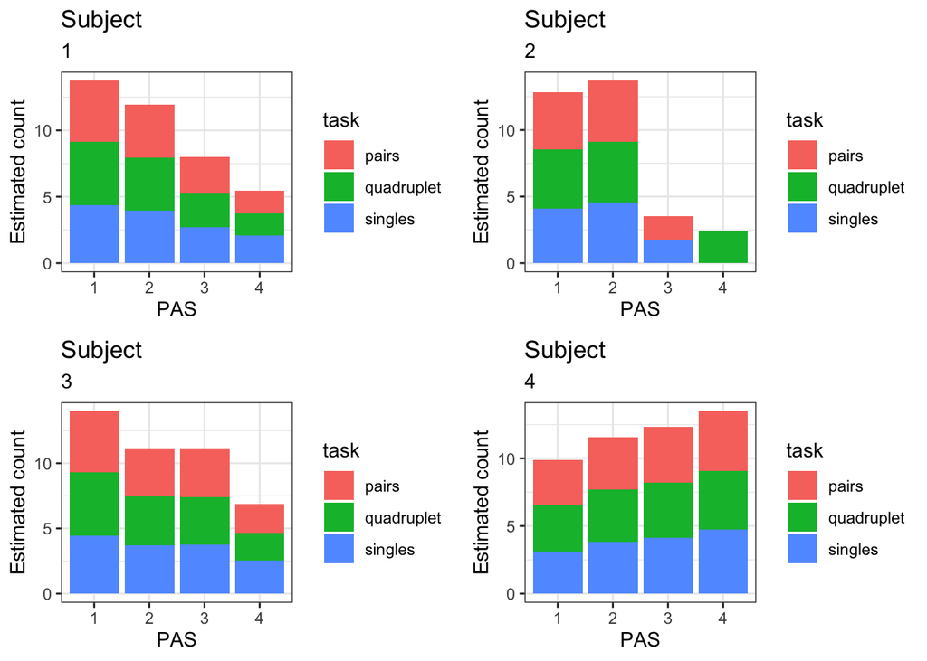

```r
#choosing subject 1, 2, 3 and 4 again :)
subject1 <- data.count %>% filter(subject == "001")
subject2 <- data.count %>% filter(subject == "002")
subject3 <- data.count %>% filter(subject == "003")
subject4 <- data.count %>% filter(subject == "004")


f <- function(i, model){
  sub.pred <- predict(model, newdata = i)
  i$est.count <- sub.pred

  p <- i %>%
    ggplot()+
    geom_bar(aes(x = pas, y = est.count, fill = task), stat = "identity")+
    theme_bw() +
    ggtitle("Subject", as.character(i[1,1])) +
    xlab("PAS")+
    ylab("Estimated count")

}

p1 <- f(subject1, m_count_new)
p2 <- f(subject2, m_count_new)
p3 <- f(subject3, m_count_new)
p4 <- f(subject4, m_count_new)

ggarrange(p1, p2, p3, p4)
```

3. Finally, fit a multilevel model that models *correct* as dependent on *task* with a unique intercept for each *subject*

```r
model3.1 <- glmer(correct ~ task + (1|subject), family = binomial, data = data)
summary(model3.1)
```

```
## Generalized linear mixed model fit by maximum likelihood (Laplace
##   Approximation) [glmerMod]
##  Family: binomial  ( logit )
## Formula: correct ~ task + (1 | subject)
##    Data: data
##
##      AIC      BIC   logLik deviance df.resid
##  19927.2  19958.4  -9959.6  19919.2    18127
##
## Scaled residuals:
##     Min      1Q  Median      3Q     Max
## -2.7426 -1.0976  0.5098  0.6101  0.9111
##
## Random effects:
##  Groups  Name        Variance Std.Dev.
##  subject (Intercept) 0.1775   0.4214
## Number of obs: 18131, groups:  subject, 29
##
## Fixed effects:
##                Estimate Std. Error z value Pr(>|z|)
## (Intercept)     1.10071    0.08387  13.124  < 2e-16 ***
## taskquadruplet -0.09825    0.04190  -2.345    0.019 *
## tasksingles     0.18542    0.04336   4.276  1.9e-05 ***
## ---
## Signif. codes:  0 '***' 0.001 '**' 0.01 '*' 0.05 '.' 0.1 ' ' 1
##
## Correlation of Fixed Effects:
##             (Intr) tskqdr
## taskqudrplt -0.256
## tasksingles -0.247  0.495
```

```
i. does _task_ explain performance?
```

```r
logit <- function(x) log(x / (1 - x))
inv.logit <- function(x) exp(x) / (1 + exp(x))

taskpair.log <- inv.logit(1.10071)
tasksingles.log <- inv.logit(1.10071 + 0.18542)
taskquad.log <- inv.logit(1.10071 - 0.09825)

tibble("Prob. of Correct in paired task" = taskpair.log, "Prob. of Correct in Singles Task" = tasksingles.log, "Prob. of Correct in Quadruplets Task" = taskquad.log)
```

```
## # A tibble: 1 x 3
##   `Prob. of Correct in pai… `Prob. of Correct in Sin… `Prob. of Correct in Quad…
##                       <dbl>                     <dbl>                      <dbl>
## 1                     0.750                     0.783                      0.732
```

*There is a probability between 70-80% chance to get a correct answer in all three trials, thus I’d argue that the task does not explain performance very well.*

```
ii. add _pas_ as a main effect on top of _task_ - what are the consequences of that?
```

```r
model3.2 <- glmer(correct ~ task + pas + (1|subject), family = binomial, data = data)
summary(model3.2)
```

```
## Generalized linear mixed model fit by maximum likelihood (Laplace
##   Approximation) [glmerMod]
##  Family: binomial  ( logit )
## Formula: correct ~ task + pas + (1 | subject)
##    Data: data
##
##      AIC      BIC   logLik deviance df.resid
##  17424.9  17479.5  -8705.5  17410.9    18124
##
## Scaled residuals:
##     Min      1Q  Median      3Q     Max
## -8.4872 -0.6225  0.3240  0.5767  1.6144
##
## Random effects:
##  Groups  Name        Variance Std.Dev.
##  subject (Intercept) 0.1979   0.4449
## Number of obs: 18131, groups:  subject, 29
##
## Fixed effects:
##                Estimate Std. Error z value Pr(>|z|)
## (Intercept)     0.08530    0.09149   0.932    0.351
## taskquadruplet -0.03055    0.04498  -0.679    0.497
## tasksingles    -0.01059    0.04688  -0.226    0.821
## pas2            0.95477    0.04420  21.599   <2e-16 ***
## pas3            1.97709    0.06221  31.780   <2e-16 ***
## pas4            3.12732    0.08626  36.254   <2e-16 ***
## ---
## Signif. codes:  0 '***' 0.001 '**' 0.01 '*' 0.05 '.' 0.1 ' ' 1
##
## Correlation of Fixed Effects:
##             (Intr) tskqdr tsksng pas2   pas3
## taskqudrplt -0.260
## tasksingles -0.226  0.489
## pas2        -0.213  0.021 -0.040
## pas3        -0.166  0.030 -0.045  0.356
## pas4        -0.123  0.016 -0.079  0.257  0.236
```

*Task doesn’t add any significant difference*

```
iii. now fit a multilevel model that models _correct_ as dependent on _pas_ with a unique intercept for each _subject_
```

```r
model3.3<- glmer(correct ~ pas + (1|subject), data = data, family = "binomial")
model3.3
```

```
## Generalized linear mixed model fit by maximum likelihood (Laplace
##   Approximation) [glmerMod]
##  Family: binomial  ( logit )
## Formula: correct ~ pas + (1 | subject)
##    Data: data
##       AIC       BIC    logLik  deviance  df.resid
## 17421.387 17460.414 -8705.694 17411.387     18126
## Random effects:
##  Groups  Name        Std.Dev.
##  subject (Intercept) 0.4451
## Number of obs: 18131, groups:  subject, 29
## Fixed Effects:
## (Intercept)         pas2         pas3         pas4
##     0.07044      0.95575      1.97892      3.12940
```

```
iv. finally, fit a model that models the interaction between _task_ and _pas_  and their main effects
```

```r
model3.4 <- glmer(correct ~ pas*task + (1|subject), data = data, family = "binomial")
model3.4
```

```
## Generalized linear mixed model fit by maximum likelihood (Laplace
##   Approximation) [glmerMod]
##  Family: binomial  ( logit )
## Formula: correct ~ pas * task + (1 | subject)
##    Data: data
##       AIC       BIC    logLik  deviance  df.resid
## 17430.974 17532.444 -8702.487 17404.974     18118
## Random effects:
##  Groups  Name        Std.Dev.
##  subject (Intercept) 0.4458
## Number of obs: 18131, groups:  subject, 29
## Fixed Effects:
##         (Intercept)                 pas2                 pas3
##            0.083740             0.963210             1.999968
##                pas4       taskquadruplet          tasksingles
##            3.049586             0.006492            -0.058967
## pas2:taskquadruplet  pas3:taskquadruplet  pas4:taskquadruplet
##           -0.049301            -0.134143            -0.095786
##    pas2:tasksingles     pas3:tasksingles     pas4:tasksingles
##            0.040476             0.079941             0.296579
```

```
v. describe in your words which model is the best in explaining the variance in accuracy
```

```r
#comparison of the  models:
#by AIC:
AIC1 <- AIC(model3.1, model3.2, model3.3, model3.4)

#residuals for each model
resid3.1 <- residuals(model3.1)
resid3.2 <- residuals(model3.2)
resid3.3 <- residuals(model3.3)
resid3.4 <- residuals(model3.4)

#comparing by standard deviation of residuals
sd_model3.1<- sqrt((sum(resid3.1)^2/length(resid3.1)-2))
sd_model3.2<- sqrt((sum(resid3.2)^2/length(resid3.2)-2))
sd_model3.3<- sqrt((sum(resid3.3)^2/length(resid3.3)-2))
sd_model3.4<- sqrt((sum(resid3.4)^2/length(resid3.4)-2))

#comparing by the residual variance:
resid.var3.1 <- sum(resid3.1^2)
resid.var3.2 <- sum(resid3.2^2)
resid.var3.3 <- sum(resid3.3^2)
resid.var3.4 <- sum(resid3.4^2)

library(tidyverse)

residuals_comparison <- tibble("model" =c("Model 3.1", "Model 3.2", "Model 3.3", "Model 3.4"), "Res Var" = c(resid.var3.1, resid.var3.2, resid.var3.3, resid.var3.4), "Res SD" = c(sd_model3.1, sd_model3.2, sd_model3.3, sd_model3.4), "AIC" = c(AIC1[1,2], AIC1[2,2], AIC1[3,2], AIC1[4,2]))

residuals_comparison
```

```
## # A tibble: 4 x 4
##   model     `Res Var` `Res SD`    AIC
##   <chr>         <dbl>    <dbl>  <dbl>
## 1 Model 3.1    19804.     19.9 19927.
## 2 Model 3.2    17297.     16.6 17425.
## 3 Model 3.3    17297.     16.6 17421.
## 4 Model 3.4    17291.     16.6 17431.
```

*I would suggest model 3.4: (correct ~ pas***task + (1|subject), family = “binomial”), since this has both the lowest residual variance and standard deviation of residuals. Thus the model must explain much of the variance it self. Intuitively, this makes rather good sense since one could imagine how subjects experience of the PAS interact with the type of task.*